# **Machine Learning Trading System**

### *Proyecto Final de Microestructuras y Sistemas de Trading*

#### **Ingeniería Financiera | ITESO**

Mayo 2021

## **Abstract**

Este proyecto fue elaborado por **Esteban Ortiz Tirado**, **Andrea Jiménez Orozco** y **Paloma Martinez**, como un trabajo final para la materia de *Microestructura y Sistemas de Trading*, la cual es parte del curriculum de la licenciatura en **Ingeniería Financiera**, ofertada por la universidad **ITESO**. En el presente trabajo plantea la creación de un **sistema de trading automatizado** cuya generación de señales se basa en un modelo de *aprendizaje de máquina (machine learning)*.

### **0.1 Librerías y Dependencias**

Para correr este notebook es necesario tener instaladas y/o en el archivo **requirements.txt** las siguientes librerías :

##### **Básicas**

- pandas>=1.1.0
- numpy>=1.19.1

##### **Visualización**

- jupyter>=1.0.0
- ipykernel
- chart_studio>=1.1
- plotly>=4.14
- matplotlib==3.2

###### **Datos y procesamiento**

- MetaTrader5==5.0.34
- tensorflow
- sklearn
- gplearn

### **0.2 Dependencias**

Para correr este notebook es necesario contar con los siguientes archivos y dependencias externas:

- **btc_h1_ytd.csv**
- **functions.py**
- **requirement.txt**

# **1.0 Introducción**

El *trading* requiere mucha atención y sensibilidad al mercado. Los traders experimentados confían en múltiples fuentes de información, como noticias, datos históricos, informes de ganancias e información privilegiada de la empresa. El riesgo es alto y es necesario considerar muchas variables. Por esa razón, algunas instituciones financieras dependen exclusivamente de las máquinas para realizar transacciones. Eso significa que una computadora con conexiones a internet de alta velocidad puede ejecutar miles de operaciones durante un día obteniendo ganancias con una pequeña diferencia en los precios. A esto se le llama *trading* de alta frecuencia. El *trading* intradía es muy riesgoso debido al comportamiento a corto plazo de los mercados que reflejan miles de millones de valores que fluctúan rápidamente en respuesta a condiciones cambiantes que se aproximan a una caminata aleatoria.

# **1.1 Redes Neuronales**

Cuando los operadores utilizan datos históricos junto con indicadores técnicos para predecir el movimiento de las acciones, buscan patrones familiares. Por ello algunos tipos de redes neuronales son excelentes para este tipo de problemas. Una red neuronal puede reconocer patrones a partir de datos históricos, tales como el precio de las acciones un determinado horizonte de tiempo.

# **2.0 Objetivos**

La intención del presente trabajo es proponer, crear y analizar un *sistema de trading* que utiliza *machine learning* para la generación señales de compra/venta del **BTC/USD** operado en **MetaTrade5**. Así como evaluar su desempeño y efectividad a lo largo de un determinado horizonte de tiempo por medio de un *backtest*.

Se propuso utilizar una **red nuronal multicapa** para reconocer patrones en datos de precios históricos, ya que estas puden tomar cualquier cantidad de funciones y aprender de ellas simultáneamente.

En este proyecto, la red tuvo que aprender de secuencias de una hora y predecir la diferencia en el precio para el siguiente periodo. Es decir, la diferencia entre el *Open* y *Close*. Si la diferencia fue positiva, se genera una señal de compra para el periodo inmediato siguiente, en el caso contrario, se genera una señal de venta.

Al momento de hacer *trading* existen cuatro elementos o consideraciones básicas para llevar un seguimiento más efectivo y organizado.

Tales como:

1. *Uso de datos*

   > **BTC/USD 1H OHLCV**
2. *Generación de señales*

   > **Red neuronal multicapa** | **Etiqueta**: diferencia en el precio entre el precio de apertura y cierre del periodo. Si este es positivo, se ejecuta una compra. Si es negativo se abre una posición de venta.
3. *Dimensionamiento de la posiciones*

   > El volumen de contratos operados en cada transacción se mantiene fijo a 1 unidad.
4. *Toma de pérdidas y ganancias*

   > Cada vez que se genere una señal de compra/venta automaticamente se toman pérdidas o ganancia de la que se encuentre actualmente abierta y se abre simultaneamente la nueva.

# **3.0 Desarrollo**

## **3.1 Inicialización de Drive en Google Colab**

```python
from google.colab import drive
drive.mount('/content/gdrive/')
```

```python
% cd gdrive/MyDrive/Colab\ Notebooks
```

```
/content/gdrive/MyDrive/Colab Notebooks
```

```python
%%capture
!pip install -r requirements.txt
!pip install gplearn
```

```python
import datetime
import pandas as pd
import matplotlib.pyplot as plt
import numpy as np
from tensorflow.keras.models import Sequential
from tensorflow.keras.layers import Dense
from tensorflow.keras.optimizers import SGD
from sklearn.metrics import r2_score
import functions as fn
```

## **3.2 Cargar los datos**

- Precios descargados desde **MetaTrader5**, utilizando su libería (API).
- Se utilizarón precios de **BTC/USD** con granularidad de 1 hora desde el inicio del año hasta el final de abril 2021

```python
# read prices from csv since connection to MTQ can´t be done in colab
df = pd.read_csv('btc_h1_ytd.csv')
df = df[['timestamp', 'open', 'high', 'low', 'close', 'volume']]
df.head()
```

|  | timestamp | open | high | low | close | volume |
| --- | --- | --- | --- | --- | --- | --- |
| 0 | 2020-12-31 19:00:00 | 29115.355 | 29136.515 | 28788.682 | 28958.222 | 4910 |
| 1 | 2020-12-31 20:00:00 | 28958.222 | 29052.614 | 28702.768 | 29013.457 | 6790 |
| 2 | 2020-12-31 21:00:00 | 29013.457 | 29492.114 | 28976.494 | 29434.036 | 7650 |
| 3 | 2020-12-31 22:00:00 | 29434.536 | 29489.490 | 29139.331 | 29213.257 | 7128 |
| 4 | 2020-12-31 23:00:00 | 29213.257 | 29363.107 | 29170.800 | 29304.666 | 6097 |

## **3.3 Ingeniería de Variables**

Utilizando el código proporcionado por Francisco, disponible en https://github.com/IFFranciscoME/GeneticMethods se generaron variables lineales y simbólicas usando un proceso de programación genética a partir del *DataFrame* original de precios.

```python
# %% Construct Linear Features (Francisco)
lin_features = fn.linear_features(p_data=df, p_memory=7, p_target='co')
# Scale linear features (robust)
lin_features = fn.data_scaler(p_data=lin_features, p_trans='standard')
# parameters for symbolic features generation process
symbolic_params = {'functions': ['sub', 'add', 'inv', 'mul', 'div', 'abs', 'log', 'sqrt'],
                   'population': 12000, 'tournament': 3000, 'hof': 30, 'generations': 5, 'n_features': 30,
                   'init_depth': (4, 10), 'init_method': 'half and half', 'parsimony': 0.001,
                   'constants': None,
                   'metric': 'pearson', 'metric_goal': 0.90,
                   'prob_cross': 0.4, 'prob_mutation_subtree': 0.5,
                   'prob_mutation_hoist': 0.05, 'prob_mutation_point': 0.05,
                   'max_samples': 1,
                   'verbose': True, 'parallelization': True, 'warm_start': True}
```

```python
# Run process
genetic_prog = fn.genetic_programed_features(p_data=lin_features, p_target='co', p_params=symbolic_params)

# Process description
sym_process = pd.DataFrame(genetic_prog['sym_data']['details'])
# best programs
best_progs = genetic_prog['sym_data']['best_programs']
best_progs
```

```
    |   Population Average    |             Best Individual              |
---- ------------------------- ------------------------------------------ ----------
 Gen   Length          Fitness   Length          Fitness      OOB Fitness  Time Left
   0    35.59        0.0190884       29         0.188919              N/A      1.32m
   1     9.83        0.0452598       30         0.221407              N/A      2.57m
   2    27.56        0.0299741       29         0.230253              N/A      1.91m
   3    27.52        0.0302755       29         0.230253              N/A     58.78s
   4    25.98         0.031463       27         0.230253              N/A      0.00s
```

|  | raw_fitness | reg_fitness | expression | depth | length |
| --- | --- | --- | --- | --- | --- |
| sym0 | 0.230253 | 0.203253 | inv(sub(add(log(add(inv(mean_vol_2), add(mul(s... | 7 | 27 |
| sym1 | 0.230253 | 0.203253 | inv(sub(add(log(add(inv(mean_vol_2), add(mul(s... | 7 | 27 |
| sym28 | 0.230253 | 0.203253 | inv(sub(add(log(add(inv(mean_vol_2), add(mul(s... | 7 | 27 |
| sym27 | 0.230253 | 0.202253 | inv(sub(add(log(add(inv(mean_vol_2), add(mul(s... | 7 | 28 |
| sym26 | 0.230253 | 0.203253 | inv(sub(add(log(add(inv(mean_vol_2), add(mul(s... | 7 | 27 |
| sym25 | 0.230253 | 0.203253 | inv(sub(add(log(add(inv(mean_vol_2), add(mul(s... | 7 | 27 |
| sym24 | 0.230253 | 0.203253 | inv(sub(add(log(add(inv(mean_vol_2), add(mul(s... | 7 | 27 |
| sym23 | 0.230253 | 0.203253 | inv(sub(add(log(add(inv(mean_vol_2), add(mul(s... | 7 | 27 |
| sym22 | 0.230253 | 0.203253 | inv(sub(add(log(add(inv(mean_vol_2), add(mul(s... | 7 | 27 |
| sym21 | 0.230253 | 0.203253 | inv(sub(add(log(add(inv(mean_vol_2), add(mul(s... | 7 | 27 |
| sym20 | 0.230253 | 0.203253 | inv(sub(add(log(add(inv(mean_vol_2), add(mul(s... | 7 | 27 |
| sym19 | 0.230253 | 0.203253 | inv(sub(add(log(add(inv(mean_vol_2), add(mul(s... | 7 | 27 |
| sym18 | 0.230253 | 0.203253 | inv(sub(add(log(add(inv(mean_vol_2), add(mul(s... | 7 | 27 |
| sym17 | 0.230253 | 0.203253 | inv(sub(add(log(add(inv(mean_vol_2), add(mul(s... | 7 | 27 |
| sym16 | 0.230253 | 0.202253 | inv(sub(add(log(add(inv(mean_vol_2), add(mul(s... | 7 | 28 |
| sym15 | 0.230253 | 0.203253 | inv(sub(add(log(add(inv(mean_vol_2), add(mul(s... | 7 | 27 |
| sym14 | 0.230253 | 0.202253 | inv(sub(add(log(add(inv(mean_vol_2), add(mul(s... | 8 | 28 |
| sym13 | 0.230253 | 0.203253 | inv(sub(add(log(add(inv(mean_vol_2), add(mul(s... | 7 | 27 |
| sym12 | 0.230253 | 0.203253 | inv(sub(add(log(add(inv(mean_vol_2), add(mul(s... | 7 | 27 |
| sym11 | 0.230253 | 0.203253 | inv(sub(add(log(add(inv(sum_vol_2), add(mul(su... | 7 | 27 |
| sym10 | 0.230253 | 0.203253 | inv(sub(add(log(add(inv(mean_vol_2), add(mul(s... | 7 | 27 |
| sym9 | 0.230253 | 0.202253 | inv(sub(add(log(add(inv(mean_vol_2), add(mul(s... | 8 | 28 |
| sym8 | 0.230253 | 0.203253 | inv(sub(add(log(add(inv(mean_vol_2), add(mul(s... | 7 | 27 |
| sym7 | 0.230253 | 0.203253 | inv(sub(add(log(add(inv(mean_vol_2), add(mul(s... | 7 | 27 |
| sym6 | 0.230253 | 0.203253 | inv(sub(add(log(add(inv(mean_vol_2), add(mul(s... | 7 | 27 |
| sym5 | 0.230253 | 0.203253 | inv(sub(add(log(add(inv(mean_vol_2), add(mul(s... | 7 | 27 |
| sym4 | 0.230253 | 0.203253 | inv(sub(add(log(add(inv(mean_vol_2), add(mul(s... | 7 | 27 |
| sym3 | 0.230253 | 0.203253 | inv(sub(add(log(add(inv(mean_vol_2), add(mul(s... | 7 | 27 |
| sym2 | 0.230253 | 0.202253 | inv(sub(add(log(add(inv(mean_vol_2), add(mul(s... | 8 | 28 |
| sym29 | 0.230253 | 0.203253 | inv(sub(add(log(add(inv(mean_vol_2), add(mul(s... | 7 | 27 |

```python
# symbolic features
sym_features = genetic_prog['sym_features']
exp_2 = pd.concat([lin_features.copy(), sym_features.copy()], axis=1)
exp_2.head()
```

| timestamp | co | ma_ol | ma_ho | ma_hl | lag_ol_1 | lag_ho_1 | lag_hl_1 | lag_vol_1 | sum_vol_1 | mean_vol_1 | lag_ol_2 | lag_ho_2 | lag_hl_2 | sd_ol_2 | sd_ho_2 | sd_hl_2 | lag_vol_2 | sum_vol_2 | mean_vol_2 | lag_ol_3 | lag_ho_3 | lag_hl_3 | sd_ol_3 | sd_ho_3 | sd_hl_3 | lag_vol_3 | sum_vol_3 | mean_vol_3 | lag_ol_4 | … |
| --- | --- | --- | --- | --- | --- | --- | --- | --- | --- | --- | --- | --- | --- | --- | --- | --- | --- | --- | --- | --- | --- | --- | --- | --- | --- | --- | --- | --- | --- | --- |
| 2021-01-01 02:00:00 | -0.176836 | -0.957090 | -1.511832 | -1.444375 | -0.628863 | -1.044457 | -1.312624 | -0.175585 | -0.346426 | -0.346426 | -0.414446 | -0.751218 | -0.911308 | -0.795372 | -0.757428 | -0.793403 | 0.469683 | -0.269985 | -0.269985 | -0.857951 | -0.628450 | -1.205949 | -0.860226 | -0.951859 | -0.632529 | 0.311832 | -0.018477 | -0.018477 | -0.220230 | … |
| 2021-01-01 03:00:00 | -0.224657 | -0.942325 | -1.517574 | -1.436924 | -0.718214 | -0.863574 | -1.257384 | -0.346467 | 0.193489 | 0.193489 | -0.629022 | -1.044465 | -1.312874 | -0.194600 | -0.768434 | -0.314310 | -0.176340 | -0.079119 | -0.079119 | -0.414149 | -0.751031 | -0.910754 | -0.532093 | -1.029489 | -0.538400 | 0.469288 | -0.116068 | -0.116068 | -0.858045 | … |
| 2021-01-01 04:00:00 | 0.399267 | -0.963695 | -1.525461 | -1.455973 | -0.076527 | -1.034067 | -0.825581 | 0.193452 | 0.199013 | 0.199013 | -0.718378 | -0.863582 | -1.257628 | -0.525782 | -0.726069 | -0.687905 | -0.347255 | 0.202984 | 0.202984 | -0.628694 | -1.044259 | -1.312210 | -0.577677 | -1.012393 | -0.626992 | -0.176766 | 0.015960 | 0.015960 | -0.414234 | … |
| 2021-01-01 05:00:00 | 0.051299 | -0.969141 | -1.659668 | -1.528286 | -0.413733 | -0.823583 | -0.963742 | 0.198976 | 0.197632 | 0.197632 | -0.076651 | -1.034076 | -0.825778 | -0.368286 | -0.234860 | -0.766270 | 0.192767 | 0.205126 | 0.205126 | -0.718037 | -0.863388 | -1.256979 | -0.422074 | -0.426041 | -0.917347 | -0.347689 | 0.207735 | 0.207735 | -0.628783 | … |
| 2021-01-01 06:00:00 | 0.133191 | -1.113660 | -1.592144 | -1.595438 | -0.895736 | -0.149419 | -0.887175 | 0.197595 | 0.064724 | 0.064724 | -0.413878 | -0.823591 | -0.963954 | -0.842904 | -0.408942 | -0.437888 | 0.198291 | 0.135672 | 0.135672 | -0.076403 | -1.033871 | -0.825247 | -0.671802 | -0.611150 | -0.713670 | 0.192358 | 0.162347 | 0.162347 | -0.718129 | … |

5 rows × 94 columns

### **3.4 Perceptrón Multicapa utilizando Tensorflow**

```python
# %% TENSORFLOW MLP
# data split
data = fn.data_split(p_data=exp_2, p_target='co', p_split=0.8)
x_train = data['train_x']
x_train = x_train.drop(labels='co', axis=1)
val_x = data['val_x']
val_x = val_x.drop(labels='co', axis=1)
y_train = data['train_y']
val_y = data['val_y']
```

```python
# model parameters
learning_rate = 0.001
epochs = 500
batch = 16
neurons = x_train.shape[1]

# Neural net
model = Sequential()
model.add(Dense(neurons, activation='sigmoid', input_dim=x_train.shape[1]))
model.add(Dense(1, activation='linear'))
opt = SGD(lr=learning_rate)
model.compile(loss='mean_squared_error', optimizer=opt, metrics=['mse'])

# fit the model
model_history = model.fit(x_train, y_train, epochs=epochs, batch_size=batch,
                          validation_data=(val_x, val_y), verbose=1)

# scores
model_score_t = model.evaluate(x_train, y_train)
model_score_v = model.evaluate(val_x, val_y)

print('Train loss:', model_score_t[0])
print('Train mse:', model_score_t[1])
print('Val loss:', model_score_v[0])
print('Val mse:', model_score_v[1])
```

```
Train loss: 0.8686589002609253
Train mse: 0.8686589002609253
Val loss: 0.545636773109436
Val mse: 0.545636773109436
```

### **3.5 Resultados del ajuste del modelo**

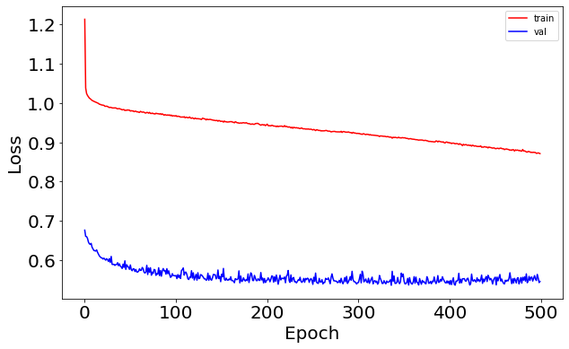

```python
fig, ax = plt.subplots(1, 1, figsize=(10, 6))
ax.plot(model_history.history['loss'], 'r', label='train')
ax.plot(model_history.history['val_loss'], 'b', label='val')
ax.set_xlabel(r'Epoch', fontsize=20)
ax.set_ylabel(r'Loss', fontsize=20)
ax.legend()
ax.tick_params(labelsize=20)
```

```python
y_hat = model.predict(x_train)
R2_score = r2_score(y_train, y_hat)
```

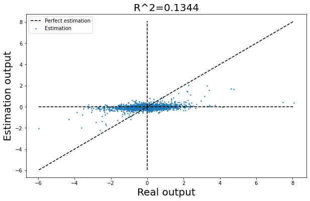

```python
x_min, x_max = min(y_train), max(y_train)
x_line = np.linspace(x_min, x_max)

fig = plt.figure(figsize=(10, 6))
plt.scatter(y_train, y_hat, s=2, label='Estimation')
plt.plot(x_line, x_line, 'k--', label='Perfect estimation')
plt.plot(x_line, 0*x_line, 'k--')
plt.plot(0*x_line, x_line, 'k--')
plt.xlabel('Real output', fontsize=20)
plt.ylabel('Estimation output', fontsize=20)
plt.title('R^2=%0.4f' % R2_score, fontsize=20)
plt.legend()
plt.show()
```

Esta grafica nos pérmite observar el **R^2** del modelo. Es decir, el ajuste o perfección de pronóstico entre el *spread* real observado contra el pronosticado.

Se puede concluir que el modelo tuvo un ajuste bastante regular. Es de destacar, que si bien el *R^2* no es particularmente alto, para los casos más extremos, el modelo predice correctamente el **signo** del cambio en precios.

Aplicado a trading, esto resulta particularmente importante ya que, por la forma en que se decidió generar las señales de compra o venta, son los valores extremos los que tienen el potencial de ocasionar ganancias o perdidas de capital importantes. Vemos que para los valores alejados del cero en el eje horizontal (valor real), el modelo predijo de forma bastante errónea su valor (eje vertical), pero de forma bastante buena su signo.

Visualmente, se puede entonces identificar que las operaciones perdedoras del modelo serían todos aquellos puntos en los cuadrantes superior izquierdo e inferior derecho. Destacamos que dichas predicciones, de signo erróneas, fueron movimientos en el precio bastante pequeños, por lo cual no es tan relevante que el modelo entregue la señal equivocada para esos casos porque el impacto sobre el capital de la cuenta es muy pequeño.

## **4.0 Backtesting (traning set)**

- El próximo paso es poner a prueba los resultados de entrenamiento dentro del sistema de *trading*, y observar cual hubiera sido la evolución del capital a lo largo del tiempo con cada una de las operaciones realizadas.
- El siguiente DataFrame muestra el *timestamp* de cada operación, la señal que se generó (1 o 0 representando compra o venta respectivamente), el precio de apertura y cierre de la operación, y el cálculo de la perdida o ganancia que se suma o resta al capital inicial de **100,000 USD**.

```python
# BACKTEST (check if you're using val_x or x_train)
operations = fn.backtest(df=df, x_train=x_train, y_hat=y_hat, trading_volume=1, capital=100000)
operations.head()
```

| date | signal | open | close | profit | cum_profit |
| --- | --- | --- | --- | --- | --- |
| 2021-01-01 02:00:00 | 0 | 29200.292 | 29125.877 | 74.415 | 100074.415 |
| 2021-01-01 03:00:00 | 1 | 29125.391 | 29027.530 | -97.861 | 99976.554 |
| 2021-01-01 04:00:00 | 0 | 29027.530 | 29235.569 | -208.039 | 99768.515 |
| 2021-01-01 05:00:00 | 0 | 29235.569 | 29273.005 | -37.436 | 99731.079 |
| 2021-01-01 06:00:00 | 0 | 29273.005 | 29350.591 | -77.586 | 99653.493 |

## **5.0 Estadisticas (training set)**

Las siguientes estadisticas nos hablan sobre el comportamiento que tuvo el *backtest* hasta el final de su periodo.

Cabe destacar que:

```python
df_estadisticas_mad = fn.f_estadisticas_mad(df_evolucion_capital=operations)
df_estadisticas_mad
```

|  | metrica | tipo | valor | descripcion |
| --- | --- | --- | --- | --- |
| 0 | sharpe_original | Cantidad | 0.215105 | Sharpe Ratio Fórmula Original |
| 1 | drawdown_capi | Fecha Inicial | 2021-04-13 22:00:00 | Fecha inicial del DrawDown de Capital |
| 2 | drawdown_capi | Fecha Final | 2021-04-15 04:00:00 | Fecha final del DrawDown de Capital |
| 3 | drawdown_capi | DrawDown $ (capital) | 4964.27 | Máxima pérdida flotante registrada |
| 4 | drawup_capi | Fecha Inicial | 2021-01-03 19:00:00 | Fecha inicial del DrawUp de Capital |
| 5 | drawup_capi | Fecha Final | 2021-04-25 21:00:00 | Fecha final del DrawUp de Capital |
| 6 | drawup_capi | DrawUP $ (capital) | 223772 | Máxima ganancia flotante registrada |

```python
df_estadisticas_ops = fn.f_estadisticas_ba(param_data=operations)
df_estadisticas_ops
```

|  | medida | valor | descripcion |
| --- | --- | --- | --- |
| 0 | Ops totales | 2013 | Operaciones totales |
| 1 | Ganadoras | 1133 | Operaciones ganadoras |
| 2 | Ganadoras_c | 505 | Operaciones ganadoras de compra |
| 3 | Ganadoras_v | 628 | Operaciones ganadoras de venta |
| 4 | Perdedoras | 880 | Operaciones perdedoras |
| 5 | Perdedoras_c | 334 | Operaciones perdedoras de compra |
| 6 | Perdedoras_v | 546 | Operaciones perdedoras de venta |
| 7 | Mediana (Profit) | 67.85 | Mediana de profit de operaciones |
| 9 | r_efectividad | 0.562842 | Ganadoras Totales/Operaciones Totales |
| 10 | r_proporcion | 1.2875 | Ganadoras Totales/Perdedoras Totales |
| 11 | r_efectividad_c | 0.250869 | Ganadoras Compras/Operaciones Totales |
| 12 | r_efectividad_v | 0.311972 | Ganadoras Ventas/Operaciones Totales |

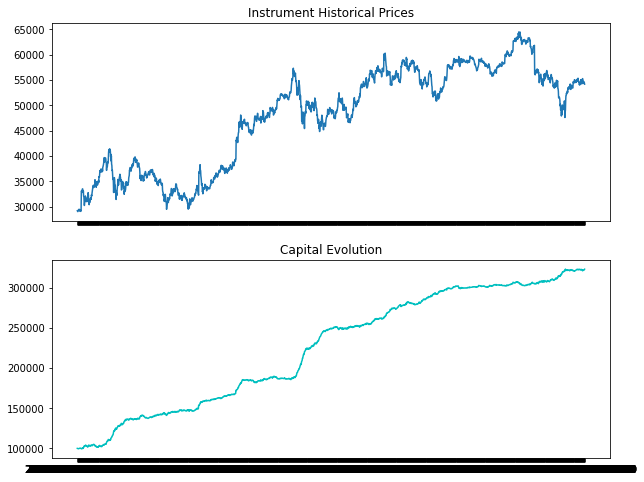

```python
fig, (ax1, ax2) = plt.subplots(2, 1, sharex=True, figsize=(10, 8))
ax1.plot(df.set_index('timestamp').close[operations.index])
ax1.set_title('Instrument Historical Prices')
ax2.plot(operations.cum_profit, 'c-')
ax2.set_title('Capital Evolution')
plt.show()
```

**Visualmente se puede observar que el modelo logró incrementar progresivamente el balance de la cuenta a lo largo del tiempo.**

## **6.0 Backtesting (validation set)**

- El próximo paso es echar a andar el sistema con el modelo ya entrenado simulando un escenario real dentro del sistema de *trading*, en donde las predicciones se hacen sobre datos que no fueron incluidos en el entrenamiento del modelo
- El siguiente *DataFrame* muestra el *timestamp* de cada operación, la señal que se generó (dirección de compra o venta), el precio de apertura y cierre, y el cálculo de la perdida o ganancia que se suma o resta al capital inicial de **100,000 USD**.

```python
operations_val = fn.backtest(df=df, x_train=val_x, y_hat=model.predict(val_x), trading_volume=1, capital=100000)
operations_val.head()
```

| date | signal | open | close | profit | cum_profit |
| --- | --- | --- | --- | --- | --- |
| 2021-04-29 02:00:00 | 0 | 53493.055 | 53812.351 | -319.296 | 99680.704 |
| 2021-04-29 03:00:00 | 1 | 53812.351 | 54292.293 | 479.942 | 100160.646 |
| 2021-04-29 04:00:00 | 1 | 54292.293 | 54351.163 | 58.870 | 100219.516 |
| 2021-04-29 05:00:00 | 0 | 54359.146 | 53882.197 | 476.949 | 100696.465 |
| 2021-04-29 06:00:00 | 1 | 53881.200 | 54507.818 | 626.618 | 101323.083 |

## **7.0 Estadisticas (validation set)**

Las siguientes estadisticas nos hablan sobre el comportamiento que tuvo el *backtest* hasta el final de su periodo.

Cabe destacar que:

```python
df_estadisticas_mad_val = fn.f_estadisticas_mad(df_evolucion_capital=operations_val)
df_estadisticas_mad_val
```

|  | metrica | tipo | valor | descripcion |
| --- | --- | --- | --- | --- |
| 0 | sharpe_original | Cantidad | 0.828297 | Sharpe Ratio Fórmula Original |
| 1 | drawdown_capi | Fecha Inicial | 2021-04-29 14:00:00 | Fecha inicial del DrawDown de Capital |
| 2 | drawdown_capi | Fecha Final | 2021-04-29 17:00:00 | Fecha final del DrawDown de Capital |
| 3 | drawdown_capi | DrawDown $ (capital) | 194.571 | Máxima pérdida flotante registrada |
| 4 | drawup_capi | Fecha Inicial | 2021-04-29 02:00:00 | Fecha inicial del DrawUp de Capital |
| 5 | drawup_capi | Fecha Final | 2021-04-29 18:00:00 | Fecha final del DrawUp de Capital |
| 6 | drawup_capi | DrawUP $ (capital) | 3908.38 | Máxima ganancia flotante registrada |

## **8.0 Resumen de operaciones**

El siguiente *DataFrame* tiene como finalidad mostrar el resultado del total de operaciones realizadas durante todo el ejercicio.

Cabe a destacar que

1. Se tuvo un *76.0%* de efectividad o acertividad en las operaciones realizadas.
2. Eso es que por cada operación perdedora, se realizaron 3.2 veces una operación ganadora.
3. El *35.2%* de las operaciones de compra fueron efectivas, mientras que el *41.1%* de las operaciones de venta se registraron igualmente con ganancia.

```python
df_estadisticas_ops_val = fn.f_estadisticas_ba(param_data=operations_val)
df_estadisticas_ops_val
```

|  | medida | valor | descripcion |
| --- | --- | --- | --- |
| 0 | Ops totales | 17 | Operaciones totales |
| 1 | Ganadoras | 13 | Operaciones ganadoras |
| 2 | Ganadoras_c | 6 | Operaciones ganadoras de compra |
| 3 | Ganadoras_v | 7 | Operaciones ganadoras de venta |
| 4 | Perdedoras | 4 | Operaciones perdedoras |
| 5 | Perdedoras_c | 0 | Operaciones perdedoras de compra |
| 6 | Perdedoras_v | 4 | Operaciones perdedoras de venta |
| 7 | Mediana (Profit) | 135.701 | Mediana de profit de operaciones |
| 9 | r_efectividad | 0.764706 | Ganadoras Totales/Operaciones Totales |
| 10 | r_proporcion | 3.25 | Ganadoras Totales/Perdedoras Totales |
| 11 | r_efectividad_c | 0.352941 | Ganadoras Compras/Operaciones Totales |
| 12 | r_efectividad_v | 0.411765 | Ganadoras Ventas/Operaciones Totales |

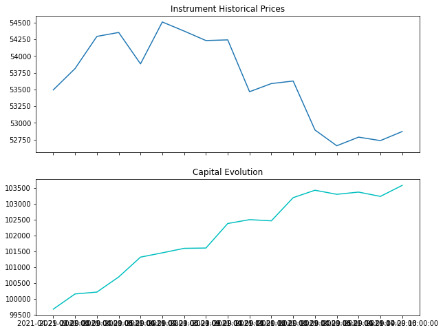

```python
fig, (ax1, ax2) = plt.subplots(2, 1, sharex=True, figsize=(10, 8))
ax1.plot(df.set_index('timestamp').close[operations_val.index])
ax1.set_title('Instrument Historical Prices')
ax2.plot(operations_val.cum_profit, 'c-')
ax2.set_title('Capital Evolution')
plt.show()
```